# MA22019 - Data Visualization (Part 1)

12 February 2025

## Motivation

Data exploration requires generating and analyzing plots of the data.

This raises the questions:

- What are the general guidelines for data visualization?
- How can we create effective plots in R?
- How do we decide which plot to produce?

**Poor graphics will prevent us from clearly communicating our findings.**

## Important

We are not aiming to impress others with beautiful pictures:

[figure not shown]

## A framework for data graphics

## The four elements of a plot

We will describe and produce data graphics in terms of four elements:

- Visual cues
- Coordinate system
- Scales
- Context

Today we focus on visual cues.

## Visual cues

We consider nine distinct visual cues

- Position (quantity)
- Length (quantity)
- Angle (quantity)
- Direction (quantity)
- Shape (category)
- Area and Volume (quantity)
- Shade and Colour (quantity or category)

## Example

**Which visual cues are used in the following plot?**

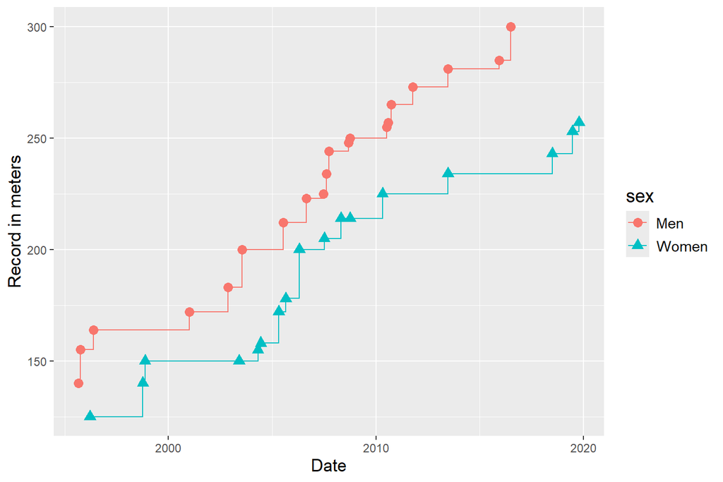

**Which conclusions can we draw?**

## Creating plots in ggplot2

## Data

Daily weather data for five Australian cities:

[interactive chart not shown]

## The plots we consider

We will today consider the following plots and produce them using ggplot2:

- Scatter plot
- Line plot
- Histogram and density plot
- Box plot and violin plot

**Which of these have you heard of?**

## Density Plot

Given data \(x_1,\ldots,x_n\) for a random variable \(X\), we estimate the probability density function of \(X\) as \[ \hat{f}(x) = \frac{1}{nh}\sum_{i=1}^{n} K\left(\frac{x-x_i}{h}\right), \]

- \(K\) is called the **kernel** and it is a probability density function
- \(h\) is the **bandwidth**

## Importance of bandwidth

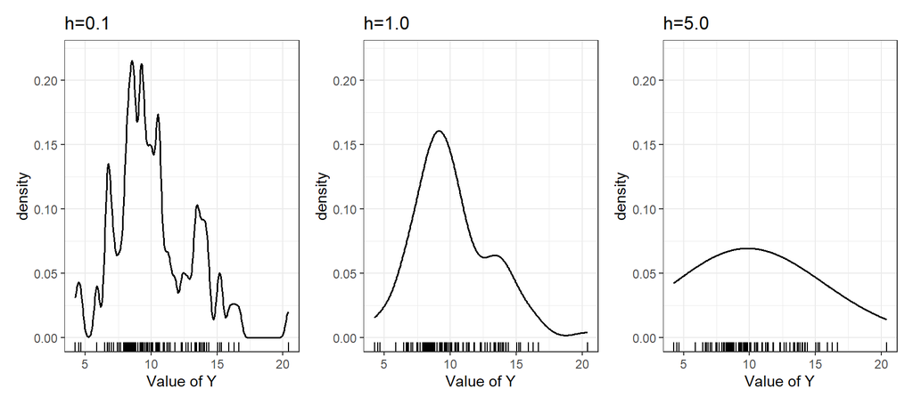

- A too small \(h\) leads to undersmoothing (left)
- A too large \(h\) leads to oversmoothing (right)

## Histogram vs Density plot

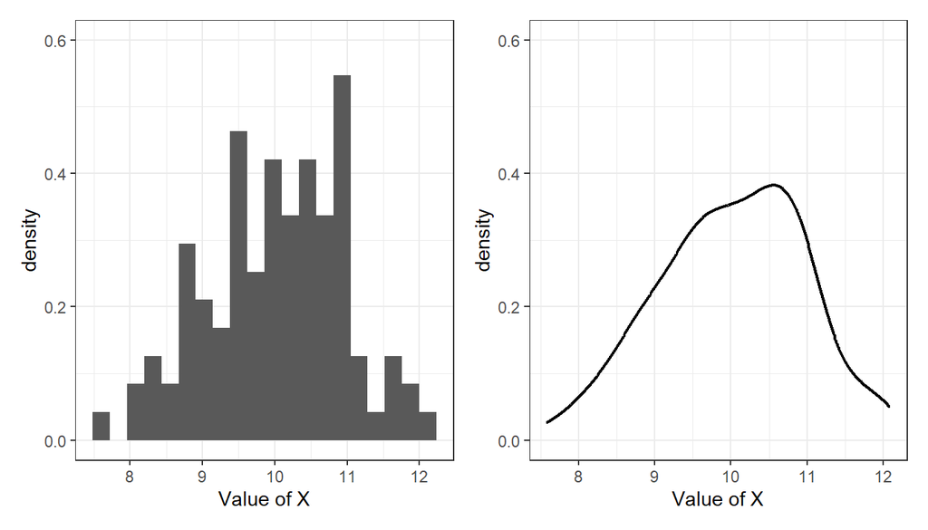

## Which plot should I choose?

While the following guidance may not always give the best choice, it often works fine in practice:

**Scatter plots:** Useful to compare the relation between two variables.

**Line plots:** Useful to explore how a variable evolves over time.

**Histogram/Density plots:** Good for exploring the distribution of a variable.

**Box plots/Violin plots:** Good to compare the distributions of multiple variables.

## Exercises

Decide which plot(s) to use in the following situations:

1. Association between amount of exercise and sleep.
2. Distribution of annual maximum temperature for Bath.
3. Impact of insulation on energy consumption.

Is **length** or **position** better in terms of our ability to perceive differences in magnitude?

## Summary

- Data graphics can be described in terms of visual cues
- Visual cues differ in how easy it is to perceive differences in magnitude
- We should not rely too much on colour as a visual cue
- Various types of plots can be produced in ggplot2

**What next?**

- On Friday we apply these techniques to another data set.
- The remaining visual cues are covered next week.